# How small is a small effect size? Reflections on the pandemic

04/06/2022

## Research findings in plain English.

Scientists are asked to communicate in plain English in order to explain their findings to non-specialists, including politicians and journalists.

This became an urgent need during the pandemic when scientists found themselves at the epicentre of public debates.

For the sake of communication scientists often resort to **translations of numerical findings into plain language**.

How well does this translation work?

## Research findings in plain English.

For example, some scientists have reassuringly told us that the negative effects of the pandemic on young people are **“small”**.

How reassured should we be? Haven’t CAMHS presentations increased (<sup>1</sup>) since the pandemic?

I will take this **“small”** as my point of departure and try to simulate the problem.

Ford TJ, John A, Gunnell D (2021) Mental health of children and young people during pandemic BMJ 2021;372,

## Standard take on effect sizes.

The most common interpretation of effect sizes comes from **Jacob Cohen**. He declared (and apparently later regretted having done so), that for an effect size *d*, defined thus:

*d* = *difference in the average between two conditions* / *standard deviation of these two conditions pooled together*

the following holds:

- **A value of 0.2 represents a small effect size.**
- A value of 0.5 represents a medium effect size.
- A value of 0.8 represents a large effect size.

Cohen J (1992) Power Analysis: A Primer, Psychol Bulletin, 112, 155

## A good study to estimate effect size.

Assume you have done the ultimate study:

- Is *longitudinal* with two periods (*pre-* and *during*)
- Accounts for *regression to the mean*
- Does careful *statistical inference*

and have arrived at an effect size about the difference in depression scores in children before and during the pandemic.

You find and effect size of **d = 0.14**.

I will try to put this **small effect** in context

Mansfield R (2022) The impact of the COVID-19pandemic on adolescentmental health: a naturalexperiment, R Soc Open Sci, doi: 10.1098/rsos.211114.

## Simulating the pandemic: data.

Consider the Mood and Feelings Questionnaire, a common depression measurement tool, as your outcome.

Let the mean pre-pandemic<sup>1</sup> in adolescents be:

**MFQ_mean_pre** = 4.90 with an SD of MFQ_sd_pre = 4.49

For an effect size close to d = 0.14 as per Mansfield<sup>2</sup>, the mean post-pandemic would have to be:

**MFQ_mean_post** = 5.53 (let’s keep the standard deviation the same)

and let the **threshold** for caseness be the standard **MFQ_threshold = 12**

1.Kwong A (2019) Examining the longitudinal nature of depressive symptoms in the Avon Longitudinal Study of Parents and Children (ALSPAC), Wellcome Open Res,https://doi.org/10.12688/wellcomeopenres.15395.2.

2.Mansfield R et al (2022) The impact of the COVID-19pandemic on adolescentmental health: a naturalexperiment, R Soc Open Sci, doi: 10.1098/rsos.211114.

## Simulating the pandemic: two distributions.

## Simulating the pandemic: two distributions.

I used a scaled beta distribution to simulate the data.

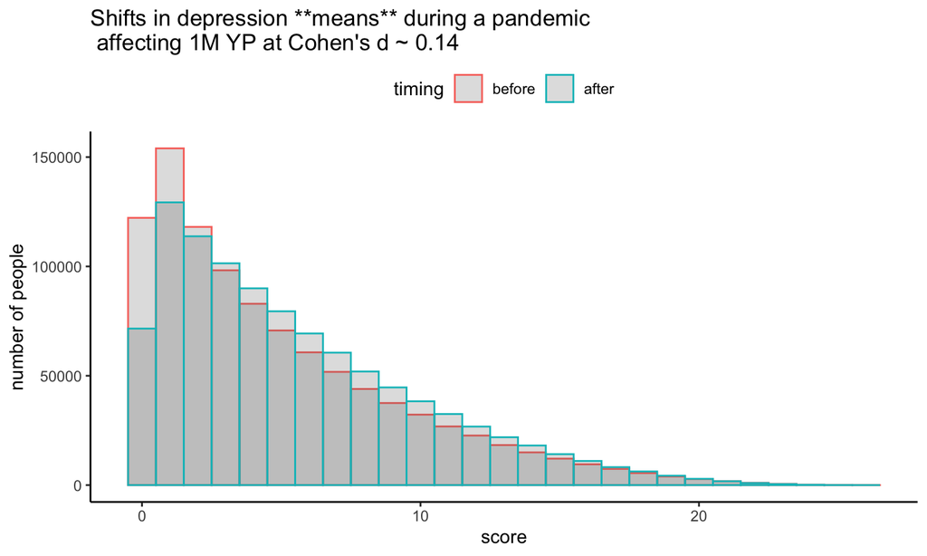

## Simulating the pandemic: two distributions.

Here you see the two distributions with the threshold. It looks fairly innocuous.

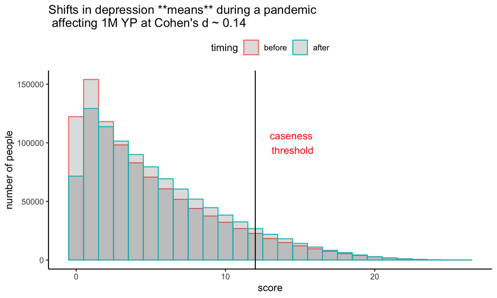

## Simulating the pandemic: what happens to the cases.

But is it that innocuous?

## Simulating the pandemic: excess cases due to the pandemic.

Here you see what the shift in mean values does to the tails.

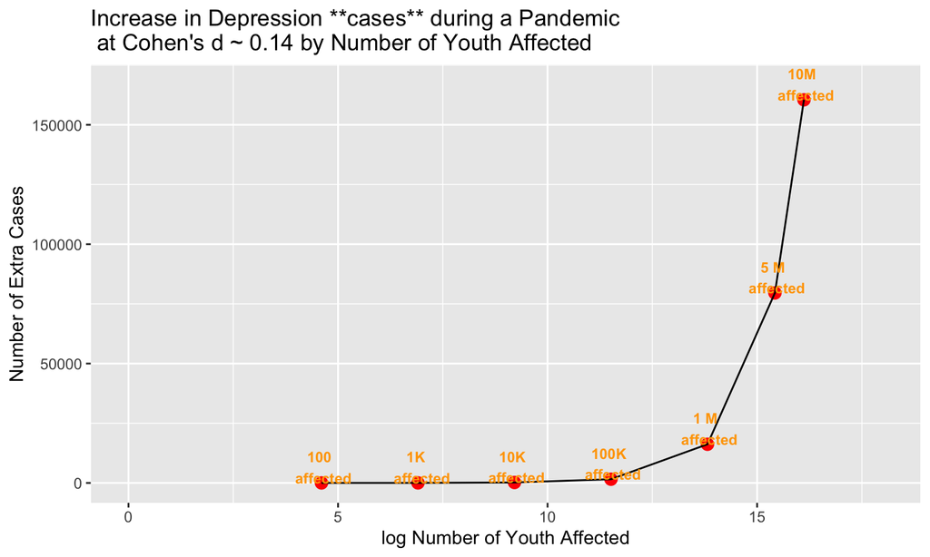

```
##   diff_pre_post_pandemic samples
## 1                      1   1e+02
## 2                     18   1e+03
## 3                    195   1e+04
## 4                   1556   1e+05
## 5                  16201   1e+06
## 6                  79578   5e+06
```

```
## # A tibble: 7 × 2
##   diff_pre_post_pandemic  samples
##                    <dbl>    <dbl>
## 1                      1      100
## 2                     18     1000
## 3                    195    10000
## 4                   1556   100000
## 5                  16201  1000000
## 6                  79578  5000000
## 7                 160473 10000000
```

## Simulating the pandemic: a reality check.

According to Mansfield et al<sup>1</sup>, the empirical **excess prevalence**, is about 1.6%.

This number corresponds to our simulation results:

e.g. for **1M** people, we get about **16K** excess cases of depression.

1.Mansfield R et al (2022) The impact of the COVID-19pandemic on adolescentmental health: a naturalexperiment, R Soc Open Sci, doi: 10.1098/rsos.211114.

## Simulating the pandemic: **small effects**

## Different graph to make effects clearer and spare room in the graph.

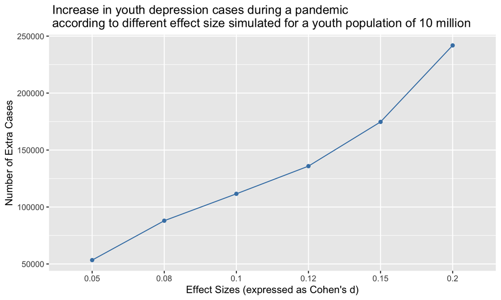

## wanted to check what happens if I incrase the sd in a simple example

```
## [1] TRUE
```

```
## [1] "incrasing the SD for post makes the difference bigger, in this example by  251011"
```

## Simulating the pandemic: **small effects**

I have now varied the small effects to give you an idea of the range.

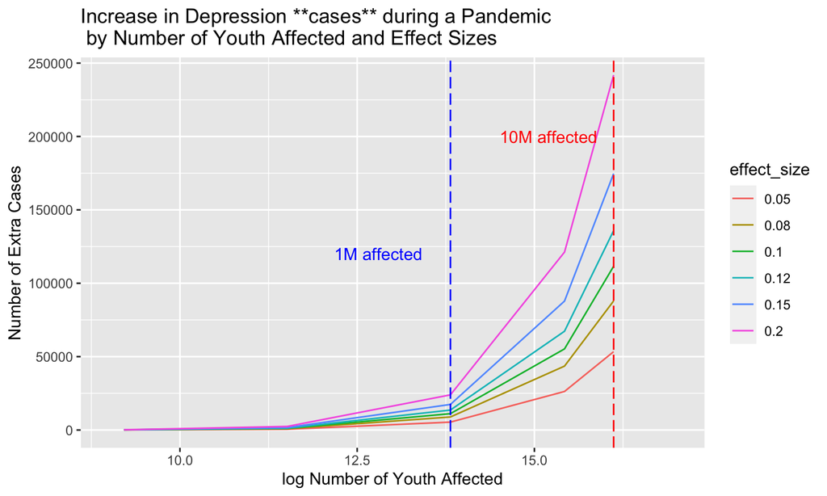

## Small effects at large scales

Small effects are **irrelevant** (mostly) in a clinic.

- That’s why the label makes sense in clinical medicine.

Small effects are **very relevant** when they scale.

- That’s why the label makes no sense in public health.

Other factors, such as *effects for what* are important too.

The approach presented here emphasises the value of simulation.

Useful Readings:  
Matthay EC (2019) Powering population health research: Considerations for plausible and actionable effect sizes. SSM Population Health, 19, 100789  
Funder DC, Ozer DJ (2019) Evaluating Effect Size in Psychological Research: Sense and Nonsense,

## Small effects and reality

The findings here have implications about how we perceive reality and how we communicate about it.

Conventions (e.g. **small effects**) and summary statitstics (e.g. **Cohen’s d**) are useful and necessary.

But they can also be highly misleading.

We propose that presentations of raw data, absolute numbers and simulations become the norm in scientific abstracts.

Last but not least: think how important small effects may be for interventions.

Greenberg MT, Abenavoli R (2017) Powering population health research: Considerations for plausible and actionable effect sizes. Journal of Research on Educational Effectiveness https://doi.org/10.1080/19345747.2016.1246632